# Remy’s Bias Looking Glass

Nik Bear Brown

11/6/2020

# Remy’s Bias Looking Glass

## Am I Biased? Creating a Twitter Looking Glass

After tweeting in support of my favorite politician, Dwayne Elizondo Mountain Dew Herbert Camacho, several people responded calling me such names as a snollygoster, a Bieber, a lickspittle, and a ninny. That if I weren’t such a tosser and twit I would support Coriolanus Snow.

Worst of all I was accussed of being biased and unfair, as I asseted they were. We got into an argument about who is more biased. Rather than argue, I decided to investigate. To accomplish this I want to build an AI looking glass which allow people to visualize bias in writing, in particular in Tweets. The AI looking glass can also be used as a mirror to look at one’s own bias.

## Rembrandt X Einstein, Remy

By the way, my name is Rembrandt X Einstein, or Remy as my friends call me. I am an AI researcher and professor at the Smarty Pants Instutite. I build predictive models using AI all of the time but sometimes wonder if the predictions they make unfairly affect people. I also wonder what my own biases are. It is time to use math to find out.

[figure not shown]

Tesla MacBook Remy

## Can Math Detect Bias?

Let’s start with a simple definition of bias. If the probability of an outcome is equal given the same inputs then this is unbiased. For example, if two people with the same qualifications have the same probability of getting a job or having the same salary then there is not bias. Conversly, if the probability differs significantly then there is not bias. For example, if two people have the same qualifications (e.g. years experience, education, etc.) they should have the same chance of getting a job.

In math, we call the outcome variable the target or dependent variable. Convention has a one call the target variable $y$, and in particalur it is usually called $\hat{y}$ or “y-hat” to indicate is is an estimate or prediction or $y$ as the true $y$ is rarely known. The input variables, thing like years experience, education, techincal skill, etc are called input variables or dependent variables and usually called $X$, we use a captial $X$ rather than a lower case $x$ to indicate that there can be many input variables, or a vector rather than a single scaler value.

This leds to one possible mathematical definition of bias.

$$\begin{equation}
Pr(\hat{y}|X_{A}) = Pr(\hat{y}|X_{B})) \enspace where \enspace X_{A} = X_{B}. \tag{Eq 1}
\end{equation}$$

The above reads the probability of y-hat is the same if the inputs are the same. This is a common sense notion, that is there is no bias when the given the same input one gets the same result.

We will continue to come back to this idea the outcome being different when the relevant input is the same as we continue to refine our exploration of bias and fairness.

[figure not shown]

Same Content with a Different Response indicates Bias

## Can We Visualize Bias?

If our notion of bias is disparate outcomes the one should be able to visualize bias. One just needs visualizations that show disparate outcomes in the data.

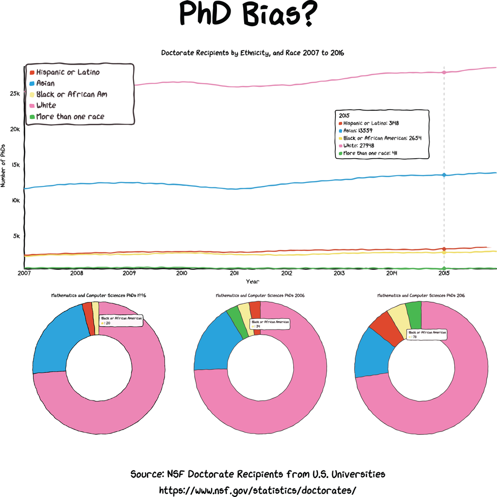

PhD Bias

The graphic above shows that those who self-indentify as White and Asian are awarded the most PhDs in the United States. This disparity has existed for decades. But is it bias?

According to the US Census those who self-indentify as White make up 76.3 percent of the population, and those who self-indentify as Black or African American make up 13.4 percent.

A logical expectation would be that those who self-indentify as White make would be awarded around 76 percent of the PhDs, and those who self-indentify as Black or African American would be awarded around 13 percent. The expectation is called a *model*. The model essentially states that individuals of all races and ethnicities should be awarded PhDs with equal probabilites, so the proporation should reflect the number of tries. If one accepts this model, does the graph indicate bias? According to the [NSF Survey of Earned Doctorates](https://www.nsf.gov/statistics/srvydoctorates/) African Americans are awarded around 5-7 percent of all doctoral degrees to students who are U.S. citizens. This means one would expect African Americans are awarded around 14 percent, but are actaully awarded around 6 percent. Further in certain fields, expecially STEM fields Blacks are vastly underrepresented among doctoral degree recipients.

## Is Bias Always Bad?

Bias just relfects the inequality of outcome. Sometimes that reflects the reality of the world. Basketball players are biased towards being tall. One reasonable model of the world would be the height helps one play basketball so this makes sense.

COVID-19 shows a clear bias with respect to age. Older people are far more likely to die from coronavirus infection.

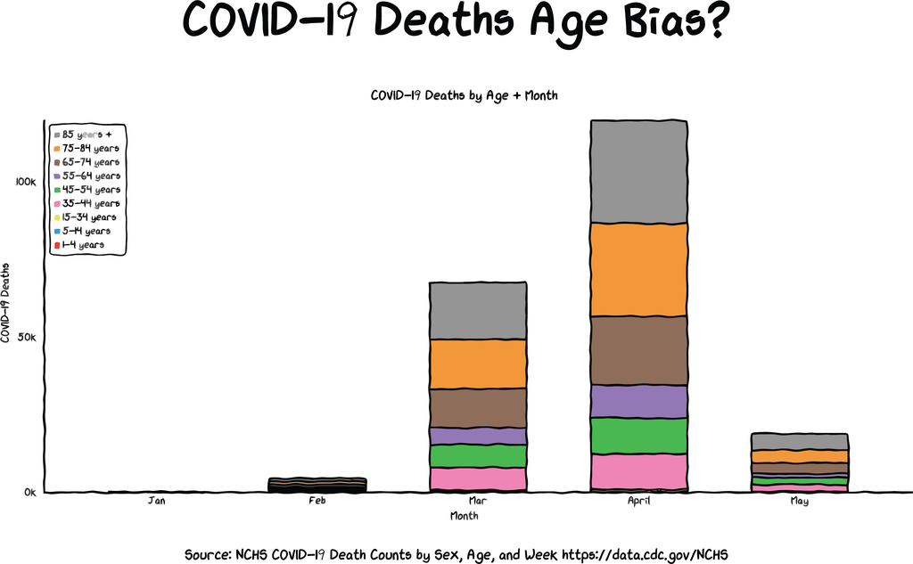

Age Bias COVID-19

## Bias versus Fairness

Bias is when there are unequal outcomes. Fairness is when the unequal outcomes are undeserved. For example, if a man and a woman were to apply for to a prestigious company for an artificial intelligence engineering job and the man had a PhD in Computer Science and the woman didn’t graaduate college most would not consider that unfair. However, if they both had essentially the same qualifications and were both highly qualified and the man were far more likely to get the job based on the only difference being gender then most would consider that unfair.

## Visualizing Ones Own Bias

One can explore this idea of responding to the same input differently based on something immaterial to the outcome or target of interest in order to develop algorithms and visualizations of bias, including understanding ones own bias. For example, if two politicians tweet essentially the same idea and one response depends more on whether the tweeter was liberal or conservative than the content of the tweet that would indicate bias.

We are going to call the variable that is immaterial to the outcome $p$. This would lead to a mathematical expression of fairness as follows:

$$\begin{equation}
Pr(\hat{y}|p) = Pr(\hat{y}). \tag{Equation 2}
\end{equation}$$

The equation would mean that the probability of the outcome would not be affected by the input $p$.

$$\begin{equation}
Pr(\hat{salary}|gender) = Pr(\hat{salary}).
\end{equation}$$

For example, ones salary would not be affected by ones gender, but rather other input such as education, years experience, skill level, etc.

## Introduction

*Discrimination* is the unequal treatment of individuals of certain groups, resulting in members of one group being deprived of benefits or opportunities. Common groups that suffer discrimination include those based on age, gender, skin colour, religion, race, language, culture, marital status, or economic condition.

The unintentional unfairness that occurs when a decision has widely different outcomes for different groups is known as _ disparate impact_. As machine learning algorithms are increasingly used to determine important real-world outcomes such as loan approval, pay rates, and parole decisions, it is incumbent on the AI community to minimize unintentional discrimination.

This tutorial discusses how _ bias_ can be introduced into the machine learning pipeline, what it means for a decision to be _ fair_, and methods to remove bias and ensure fairness.